# Project0_OptmicalChopstickLength

Rajiv Kumar

Saturday, August 15, 2015

In This document , we will see how to perform ANOVA test on a groups of samples means to analyze if they come from the same population or from the different population. Lets first import data in to R

```r
chopdata<-read.csv("chopstick-effectiveness.csv" , header = T)
```

```r
list.files()
```

```
## [1] "chopstick-effectiveness.csv"       "chopstick-effectiveness.html"
## [3] "chopstick-effectiveness.RMD"       "Data_Analyst_ND_Project_v1.2.zip"
## [5] "Data_Analyst_ND_Project_v1.3.zip"  "Data_Analyst_ND_Project0.html"
## [7] "Data_Analyst_ND_Project0_v1.0.zip" "Data_Analyst_ND_Project0_v1.1.zip"
```

```r
str(chopdata)
```

```
## 'data.frame':    186 obs. of  3 variables:
##  $ Food.Pinching.Efficiency: num  19.6 27.2 28.8 31.2 21.9 ...
##  $ Individual              : int  1 2 3 4 5 6 7 8 9 10 ...
##  $ Chopstick.Length        : int  180 180 180 180 180 180 180 180 180 180 ...
```

Lets first see some descriptive statistics . In the results , we see that length 240 has the highest mean value. lets dig deeper.

```r
aggregate(chopdata$Food.Pinching.Efficiency, list(chopdata$Chopstick.Length), mean)
```

```
##   Group.1        x
## 1     180 24.93516
## 2     210 25.48387
## 3     240 26.32290
## 4     270 24.32387
## 5     300 24.96806
## 6     330 23.99968
```

```r
aggregate(chopdata$Food.Pinching.Efficiency, list(chopdata$Chopstick.Length), median)
```

```
##   Group.1     x
## 1     180 26.35
## 2     210 25.42
## 3     240 26.43
## 4     270 24.50
## 5     300 25.09
## 6     330 23.63
```

```r
aggregate(chopdata$Food.Pinching.Efficiency, list(chopdata$Chopstick.Length), sd)
```

```
##   Group.1        x
## 1     180 4.020612
## 2     210 4.116344
## 3     240 4.457579
## 4     270 3.713268
## 5     300 3.560044
## 6     330 4.198898
```

Now lets try to do box plots for each category of length to see , if we see any trend. From the box plots , we see that length 240 has relatively high median than other category but we need to analyze further to see , if that really true and its not by chance.

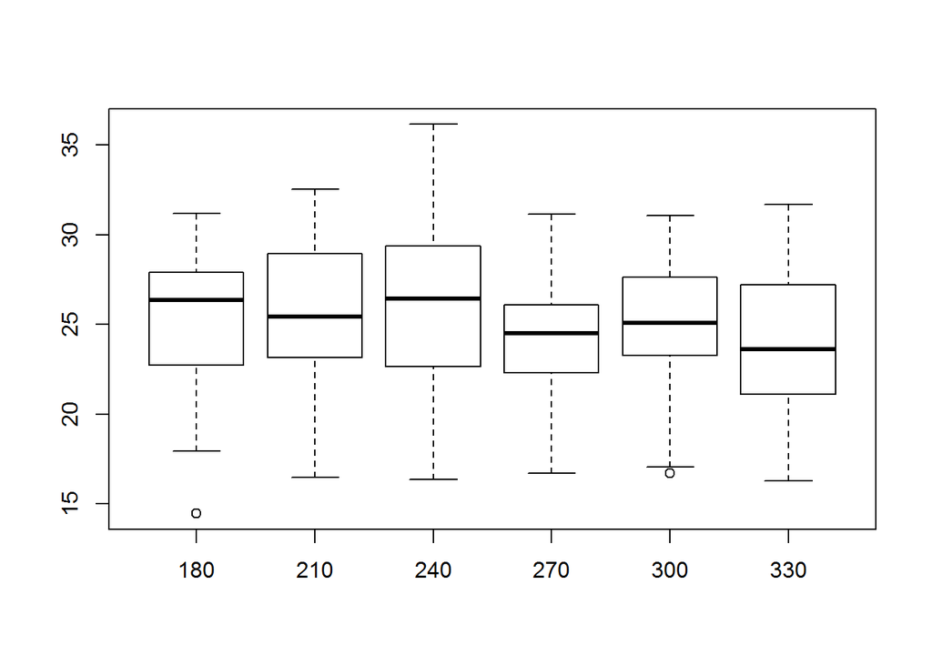

Now , lets draw line plot to see , if we notice any trend

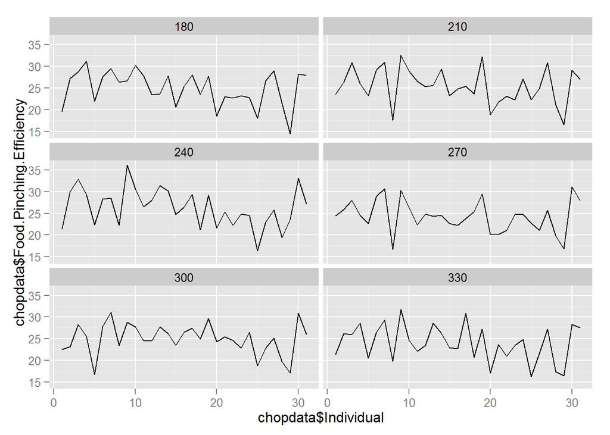

```r
library(ggplot2)
ggplot(aes(x=chopdata$Individual, y = chopdata$Food.Pinching.Efficiency),data=chopdata)+geom_line() + facet_wrap(~Chopstick.Length,nrow=4)
```

Now lets connect the all plots in single and group them via chopstick length to see , if we see something useful.our line plot suggest that Optimal Food efficiency is achieved for chopstick length=240 mm(shown in green line). It seems to align somewhat with observation through box plots. However, lets dig more deep and do ANOVA to see if our hypothesis is really true.

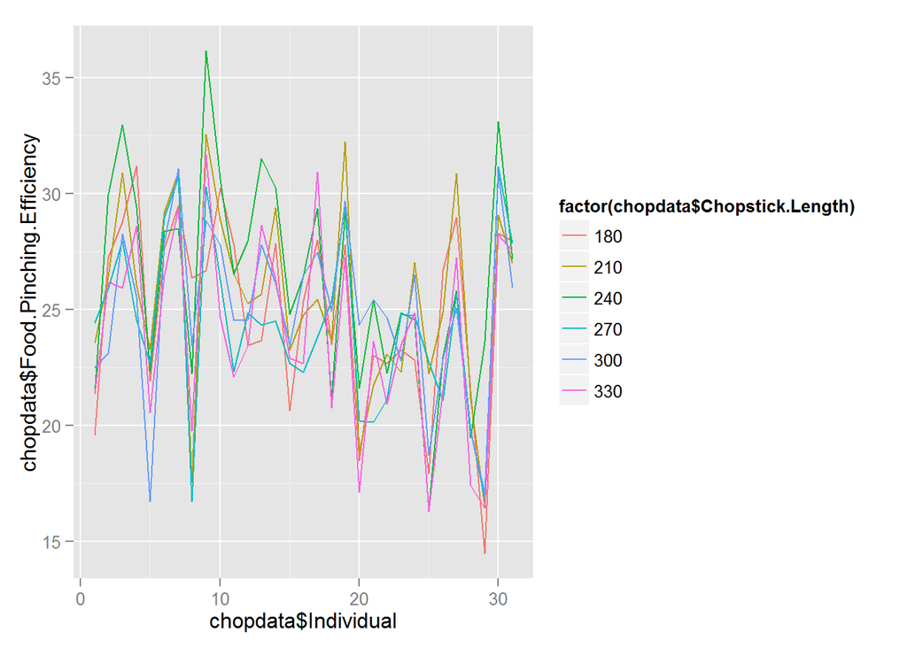

```r
ggplot(aes(x=chopdata$Individual, y = chopdata$Food.Pinching.Efficiency ),data=chopdata)+geom_line(aes(group = chopdata$Chopstick.Length,color=factor(chopdata$Chopstick.Length)))
```

Lets do ANOVA - for all combinations

```r
optimallenAnova<-aov(chopdata$Food.Pinching.Efficiency~factor(chopdata$Chopstick.Length))
summary(optimallenAnova)
```

```
##                                    Df Sum Sq Mean Sq F value Pr(>F)
## factor(chopdata$Chopstick.Length)   5  106.9   21.37   1.321  0.257
## Residuals                         180 2912.2   16.18
```

```r
TukeyHSD(optimallenAnova)
```

```
##   Tukey multiple comparisons of means
##     95% family-wise confidence level
##
## Fit: aov(formula = chopdata$Food.Pinching.Efficiency ~ factor(chopdata$Chopstick.Length))
##
## $`factor(chopdata$Chopstick.Length)`
##                diff       lwr       upr     p adj
## 210-180  0.54870968 -2.394358 3.4917770 0.9945720
## 240-180  1.38774194 -1.555325 4.3308092 0.7517263
## 270-180 -0.61129032 -3.554358 2.3317770 0.9910392
## 300-180  0.03290323 -2.910164 2.9759705 1.0000000
## 330-180 -0.93548387 -3.878551 2.0075834 0.9421005
## 240-210  0.83903226 -2.104035 3.7820995 0.9632993
## 270-210 -1.16000000 -4.103067 1.7830673 0.8659924
## 300-210 -0.51580645 -3.458874 2.4272608 0.9959402
## 330-210 -1.48419355 -4.427261 1.4588737 0.6946306
## 270-240 -1.99903226 -4.942100 0.9440350 0.3715134
## 300-240 -1.35483871 -4.297906 1.5882286 0.7702024
## 330-240 -2.32322581 -5.266293 0.6198415 0.2102260
## 300-270  0.64419355 -2.298874 3.5872608 0.9886062
## 330-270 -0.32419355 -3.267261 2.6188737 0.9995657
## 330-300 -0.96838710 -3.911454 1.9746802 0.9333422
```